# Init

```python
import numpy as np
import matplotlib.pyplot as plt
from scipy import stats
```

```python
kb = 3.1668105e-06 # in hartree
ha2ev = 27.211386
kbev = kb*ha2ev # in eV
T0=90
natomfcc=1440
natomsf=1320
nfreefcc=(natomfcc-1)*3
nfreesf=(natomsf-1)*3
```

## The energy units in this notebook is in eV, unless specified otherwise

# 0K results

```python
U0fcc=-6408.37671808278  # in eV
U0sf=-5872.03815551313
```

# The free energy of the reference harmonic system with fixed mass at 90K

### $A_\text{h}(T_0)=k_B T_0\sum_{i=1}^{3N-3}\ln(\dfrac{\hbar \omega_i}{k_B T_0})$

```python
eva = np.loadtxt("ipi-90K/fcc-phonon/fcc-90K.eigval")
# The square root of the eigenvalues of the phonon modes is the frequency in the unit of hartree
AharmfccT0 = ha2ev*T0*kb*np.log(np.sqrt(eva[3:])/(T0*kb)).sum()
print AharmfccT0
```

```
39.7857564885
```

```python
eva = np.loadtxt("ipi-90K/sf-phonon/sf-90K.eigval")
# The square root of the eigenvalues of the phonon modes is the frequency in the unit of hartree
AharmsfT0 = ha2ev*T0*kb*np.log(np.sqrt(eva[3:])/(T0*kb)).sum()
print AharmsfT0
```

```
36.4324033105
```

# Anharmonic correction of A at 90K

```python
dhdlfcc = np.loadtxt("ipi-90K/fcc-ti-lambda/fcc.dhdl")
it=0.0
iterror=0.0
for i in xrange(len(dhdlfcc)-1):
    #print dhdlfcc[i,0],dhdlfcc[i,1]
    it += 0.5*(dhdlfcc[i,1]+dhdlfcc[i+1,1])*(dhdlfcc[i+1,0]-dhdlfcc[i,0])
    iterror += 0.5*(dhdlfcc[i,2]**2.+dhdlfcc[i,2]**2.)*(dhdlfcc[i+1,0]-dhdlfcc[i,0])
#print it, iterror
AanhfccT0=it
AanhfccT0error=iterror
AfccT0=AharmfccT0+AanhfccT0
print AharmfccT0, U0fcc, AanhfccT0
print AfccT0, "+/-", AanhfccT0error
```

```
39.7857564885 -6408.37671808 -6408.1801805
-6368.39442401 +/- 1.43889662525e-07
```

```python
dhdlsf = np.loadtxt("ipi-90K/sf-ti-lambda/sf.dhdl")
it=0.0
iterror=0.0
for i in xrange(len(dhdlsf)-1):
    it += 0.5*(dhdlsf[i,1]+dhdlsf[i+1,1])*(dhdlsf[i+1,0]-dhdlsf[i,0])
    iterror += 0.5*(dhdlsf[i,2]**2.+dhdlsf[i,2]**2.)*(dhdlsf[i+1,0]-dhdlsf[i,0])
#print it, iterror
AanhsfT0=it
AanhsfT0error=iterror
AsfT0=AharmsfT0+AanhsfT0
print AharmsfT0, U0sf, AanhsfT0
print AsfT0, "+/-", AanhsfT0error
```

```
36.4324033105 -5872.03815551 -5871.966848
-5835.53444469 +/- 8.33112122485e-08
```

# Transform the Helmholtz free energy to the Gibbs free energy

#### We used the isothermal-isobaric ensemble (NPT) in the simulations with zero external pressure, and allowed the 3 dimensions of the orthorhombic simulation cell are allowed to fluctuate independently. In this case we have

#### $G(P,T) = A (\textbf{h},T) + P \text{det}(\textbf{h}) + k_B T \ln \rho(\textbf{h}|P,T)$.

#### As $P=0$ in our case, so here we only need to compute $k_B T \ln \rho(\textbf{h}|P,T)$

#### For convinience, we used a bash script (processrhoxyz.sh) to compute this quantity.

```python
A2GfccT0=[0.0954334, 0.000648192]
A2GsfT0=[0.0922619, 0.000791661]

GfccT0=AfccT0+A2GfccT0[0]
GfccT0error=AanhfccT0error+A2GfccT0[1]
print "Gfcc90K:",GfccT0, "+/-", GfccT0error

GsfT0=AsfT0+A2GsfT0[0]
GsfT0error=AanhsfT0error+A2GsfT0[1]
print "Gsf 90K:",GsfT0, "+/-", GsfT0error
```

```
Gfcc90K: -6368.29899061 +/- 0.000648335889663
Gsf 90K: -5835.44218279 +/- 0.000791744311212
```

# Thermodynamic Intergation at NPT

## $-T_1\int_{T_0}^{T_1} \dfrac{\left<\delta H\right>_{P,T}}{ T^2} dT=-T_1\int_{\ln T_0}^{\ln T_1} \left<\delta H\right>_{P,T}e^{-y} dy$,

## In our case P=0 so $H=U$

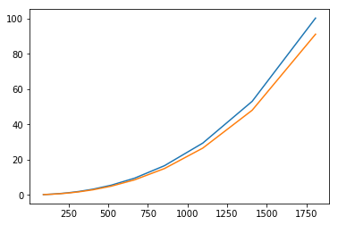

```python
dhnptlist = np.sort(np.loadtxt("lammps-npt/PE.list"), axis=0)
#print dhnptlist
ttnpt = dhnptlist[12:-2,0]
ltnpt = np.log(ttnpt)
#print ttnpt

dhfcc = dhnptlist[12:-2,1]
dhfccerror = dhnptlist[12-2:,2]
dhsf = dhnptlist[12:-2,3]
dhsferror = dhnptlist[12:-2,4]
for a in xrange(len(ttnpt)):
    dhfcc[a] += -U0fcc- ttnpt[a]*kbev*nfreefcc/2.
    dhsf[a] += -U0sf- ttnpt[a]*kbev*nfreesf/2.

plt.plot(ttnpt,dhfcc)
plt.plot(ttnpt,dhsf)
plt.show()
```

#### TI wrt T, starting at T_0=90K

```python
intdhfcc=np.zeros((len(ttnpt)-1,3))
it=0.0
iterror=0.0
for i in xrange(len(ttnpt)-1):
    T1=ttnpt[i+1]
    it += 0.5*(dhfcc[i]/ttnpt[i]+dhfcc[i+1]/ttnpt[i+1])*(ltnpt[i+1]-ltnpt[i])
    iterror += 0.5*((dhfccerror[i]/ttnpt[i])**2.+(dhfccerror[i+1]/ttnpt[i+1])**2.)*(ltnpt[i+1]-ltnpt[i])
    intdhfcc[i,0]=T1
    intdhfcc[i,1]=-it*T1
    intdhfcc[i,2]=np.sqrt(iterror)*T1
#print intdhfcc
#plt.plot(intdhfcc[:,0],intdhfcc[:,1])
#plt.show()
```

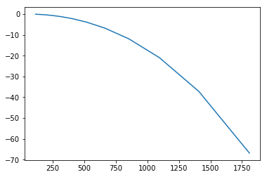

```python
intdhsf=np.zeros((len(ttnpt)-1,3))
it=0.0
iterror=0.0
for i in xrange(len(ttnpt)-1):
    T1=ttnpt[i+1]
    it += 0.5*(dhsf[i]/ttnpt[i]+dhsf[i+1]/ttnpt[i+1])*(ltnpt[i+1]-ltnpt[i])
    iterror += 0.5*((dhsferror[i]/ttnpt[i])**2.+(dhsferror[i+1]/ttnpt[i+1])**2.)*(ltnpt[i+1]-ltnpt[i])
    intdhsf[i,0]=T1
    intdhsf[i,1]=-it*T1
    intdhsf[i,2]=np.sqrt(iterror)*T1
#print intdhsf
plt.plot(intdhsf[:,0],intdhsf[:,1])
plt.show()
```

## Now we put all the pieces together

## From the paper we have

### $\dfrac{G(P,T_1)}{k_B T_1} = \dfrac{G(P,0)}{k_B T_1}+ \dfrac{G(P,T_0) - G(P,0)}{k_B T_0} -(3N-3) \ln(\dfrac{T_1}{T_0})- \int_{T_0}^{T_1} \dfrac{\left<\delta H\right>_{P,T}}{k_B T^2} dT.$

### $G(P,T_1) = G(P,0)+ \dfrac{T_1}{T_0}(G(P,T_0) - G(P,0)) -(3N-3)k_B T_1 \ln(\dfrac{T_1}{T_0})-T_1\int_{\ln T_0}^{\ln T_1} \left<\delta H\right>_{P,T}e^{-y} dy$

### Note: These expressions are for systems with contrained center of mass

```python
Gfcc=np.zeros((len(ttnpt)-1,3))
for i in xrange(len(ttnpt)-1):
    T1=intdhfcc[i,0]
    Gfcc[i,0]=T1
    Gfcc[i,1]=intdhfcc[i,1]+U0fcc+(T1/T0)*(GfccT0-U0fcc)-nfreefcc*kbev*T1*np.log(T1/T0)
    Gfcc[i,2]=intdhfcc[i,2]+(T1/T0)*GfccT0error
print Gfcc
```

```
[[  1.15000000e+02  -6.36770769e+03   1.15173087e-03]
 [  1.48000000e+02  -6.37001975e+03   1.69722240e-03]
 [  1.90000000e+02  -6.37694251e+03   2.35325043e-03]
 [  2.44000000e+02  -6.39096429e+03   3.17187676e-03]
 [  3.14000000e+02  -6.41585367e+03   4.24717164e-03]
 [  4.03000000e+02  -6.45608665e+03   5.64812163e-03]
 [  5.18000000e+02  -6.51927665e+03   7.50386825e-03]
 [  6.65000000e+02  -6.61459854e+03   9.93613477e-03]
 [  8.54000000e+02  -6.75625470e+03   1.31471593e-02]
 [  1.09600000e+03  -6.96285693e+03   1.73755283e-02]
 [  1.40800000e+03  -7.26327210e+03   2.30016124e-02]
 [  1.80800000e+03  -7.69536600e+03   3.04811242e-02]]
```

```
[[  1.15000000e+02  -5.83493672e+03   1.45613881e-03]
 [  1.48000000e+02  -5.83710279e+03   2.11939509e-03]
 [  1.90000000e+02  -5.84350595e+03   2.96222848e-03]
 [  2.44000000e+02  -5.85642995e+03   4.06987814e-03]
 [  3.14000000e+02  -5.87933264e+03   5.54780356e-03]
 [  4.03000000e+02  -5.91631819e+03   7.48723307e-03]
 [  5.18000000e+02  -5.97436996e+03   1.00802976e-02]
 [  6.65000000e+02  -6.06189889e+03   1.35169266e-02]
 [  8.54000000e+02  -6.19192395e+03   1.81170136e-02]
 [  1.09600000e+03  -6.38149758e+03   2.42818111e-02]
 [  1.40800000e+03  -6.65706520e+03   3.26968507e-02]
 [  1.80800000e+03  -7.05333284e+03   4.46083333e-02]]
```

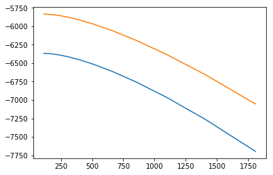

```python
Gsf=np.zeros((len(ttnpt)-1,3))
for i in xrange(len(ttnpt)-1):
    T1=intdhsf[i,0]
    Gsf[i,0]=T1
    Gsf[i,1]=intdhsf[i,1]+U0sf+(T1/T0)*(GsfT0-U0sf)-nfreesf*kbev*T1*np.log(T1/T0)
    Gsf[i,2]=intdhsf[i,2]+(T1/T0)*GsfT0error

print Gsf

plt.plot(Gfcc[:,0],Gfcc[:,1])
plt.plot(Gsf[:,0],Gsf[:,1])
plt.show()
```

# This the free energy associated with the center of mass

### $\Delta A_{cm}(N, V, T)=-k_B T\left(\ln\dfrac{V}{N \Lambda^3}+\dfrac{3}{2}\ln N\right)$

### $ \Lambda=(2\pi \hbar^2/(atomicmass\times dalton \times k_B T))^{1/2}=17.458218 /\sqrt{T*atomicmass}~A$

### For FCC Ni At 0K, $V/N=10.9036 A^3$

### Now we add this to the free energy in order to retrieve the free energy of the uncontrained system

```python
massni=58.6934
vdivideN=10.9036
for i in xrange(len(Gfcc)):
    T1 = Gfcc[i,0]
    acm = -kbev*T1*(np.log(vdivideN/(17.458218/np.sqrt(T1*massni))**3.)+1.5*np.log(natomfcc))
    #print T1, acm
    Gfcc[i,1] += acm
print Gfcc
```

```
[[  1.15000000e+02  -6.36788552e+03   1.15173087e-03]
 [  1.48000000e+02  -6.37025343e+03   1.69722240e-03]
 [  1.90000000e+02  -6.37724864e+03   2.35325043e-03]
 [  2.44000000e+02  -6.39136532e+03   3.17187676e-03]
 [  3.14000000e+02  -6.41637997e+03   4.24717164e-03]
 [  4.03000000e+02  -6.45677514e+03   5.64812163e-03]
 [  5.18000000e+02  -6.52017841e+03   7.50386825e-03]
 [  6.65000000e+02  -6.61577767e+03   9.93613477e-03]
 [  8.54000000e+02  -6.75779657e+03   1.31471593e-02]
 [  1.09600000e+03  -6.96487107e+03   1.73755283e-02]
 [  1.40800000e+03  -7.26590520e+03   2.30016124e-02]
 [  1.80800000e+03  -7.69880558e+03   3.04811242e-02]]
```

```python
for i in xrange(len(Gsf)):
    T1 = Gsf[i,0]
    acm = -kbev*T1*(np.log(vdivideN/(17.458218/np.sqrt(T1*massni))**3.)+1.5*np.log(natomsf))
    #print T1, acm
    Gsf[i,1] += acm
print Gsf
```

```
[[  1.15000000e+02  -5.83511325e+03   1.45613881e-03]
 [  1.48000000e+02  -5.83733481e+03   2.11939509e-03]
 [  1.90000000e+02  -5.84380994e+03   2.96222848e-03]
 [  2.44000000e+02  -5.85682823e+03   4.06987814e-03]
 [  3.14000000e+02  -5.87985542e+03   5.54780356e-03]
 [  4.03000000e+02  -5.91700214e+03   7.48723307e-03]
 [  5.18000000e+02  -5.97526589e+03   1.00802976e-02]
 [  6.65000000e+02  -6.06307055e+03   1.35169266e-02]
 [  8.54000000e+02  -6.19345622e+03   1.81170136e-02]
 [  1.09600000e+03  -6.38349940e+03   2.42818111e-02]
 [  1.40800000e+03  -6.65968247e+03   3.26968507e-02]
 [  1.80800000e+03  -7.05675209e+03   4.46083333e-02]]
```

# Now compute stacking fault free energy

### $G_\text{SF} = G_\text{sf} - \dfrac{N_\text{sf}}{N_\text{fcc}} G_\text{fcc}$

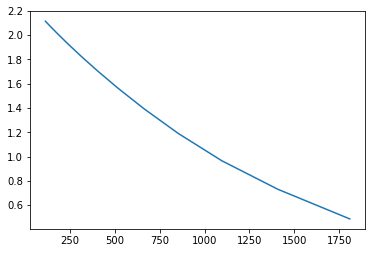

```python
Gv=np.zeros((len(ttnpt)-1,3))
for i in xrange(len(ttnpt)-1):
    T1=Gsf[i,0]
    Gv[i,0]=T1
    Gv[i,1]=Gsf[i,1]-Gfcc[i,1]*natomsf/natomfcc
    Gv[i,2]=np.sqrt(Gsf[i,2]**2.0+Gfcc[i,2]**2.0)

plt.plot(Gv[:,0],Gv[:,1])
plt.show()
```